# Assignment 2 - Q2

21315316

# Time Series for Weather Stations using Shiny

## 1 Introduction

The objective of this project was to improve upon an assignment I was given to perform time series analysis on four weather stations. Plotting data for four weather stations is straightforward, but if the user wants to choose specific stations, what alterations would be needed? Can this process be made easier using a Shiny app?

This section will perform an in-depth analysis of rainfall per month from four weather stations across Ireland,specifically Belfast, Dublin Airport, University College Galway, and Cork Airport. By pairing this comprehensive dataset with an interactive and intuitive map, we can perform a critical analysis of both long-term and short-term trends.

This blog’s interactive tools and visuals will allow you to:

- Examine monthly rainfall data through dynamic time series graphs
- Explore geographical variations using an interactive map of Ireland with a universal time selector
- Compare rainfall patterns across multiple stations simultaneously and individually
- Create graphs for analysis for chosen stations

```r
# Load the GeoJSON file
rainstat_st <- st_read('weather_stations.geojson', quiet = TRUE)

# Convert to data frame and select relevant columns
rainstat<- rainstat_st %>%
    as.data.frame() %>%
    select(Year, Month, Rainfall, Station)
```

## 2 Exploration of the data:

In this section, I will perform analysis on the weather station and rainfall utilizing the following:

- **Boxplot Analysis**: Visualize and compare the distribution of rainfall across the four stations, highlighting variations in median values and data spread.
- **Long-term Trend Analysis**: Investigate the overall rainfall trends from 1850 to 2014, identifying any significant changes or patterns over time.
- **Seasonal Trend Analysis**: Explore monthly rainfall patterns to uncover any recurring seasonal trends across the stations.

### 2.1 Boxplot for stations

First, let’s analyze the dataset, focusing on the mean and general characteristics of the data we are working with. Employing a box plot provides a comprehensive summary of the data across the four weather stations:

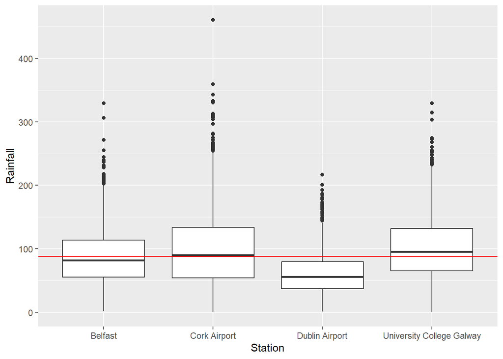

```r
rainstat%>%
    filter(Station %in% c("Belfast","Dublin Airport","University College Galway","Cork Airport") )%>%
    summarise(mean_rainfall = mean(Rainfall, na.rm = TRUE)) %>%
    pull(mean_rainfall) -> mean_rainfall

rainstat%>%
    filter(Station %in% c("Belfast","Dublin Airport","University College Galway","Cork Airport") )%>%
    ggplot(aes(x=Station, y=Rainfall)) +
    geom_boxplot() + geom_hline(aes(yintercept = mean_rainfall), color="red")
```

```r
rainstat%>%
    filter(Station %in% c("Belfast","Dublin Airport","University College Galway","Cork Airport") )%>%
    group_by(Station) %>%
    summarise(
        Q1 = quantile(Rainfall, 0.25),
        Q3 = quantile(Rainfall, 0.75),
        IQR = IQR(Rainfall),
        lower_bound = Q1 - 1.5 * IQR,
        upper_bound = Q3 + 1.5 * IQR,
        outliers = sum(Rainfall < lower_bound | Rainfall > upper_bound)
    )
```

```
## # A tibble: 4 × 7
##   Station                Q1    Q3   IQR lower_bound upper_bound outliers
##   <chr>               <dbl> <dbl> <dbl>       <dbl>       <dbl>    <int>
## 1 Belfast              55.6 114.   58.1       -31.6        201.       29
## 2 Cork Airport         54.4 134.   79.5       -64.9        253.       32
## 3 Dublin Airport       37.3  79.7  42.4       -26.3        143.       42
## 4 University College…  65.2 132.   66.6       -34.7        232.       22
```

### 2.2 Long-term Rainfall Trends

From the 1940s onwards, a slow but steady increase in rainfall has been observed, this tend upwards could be linked to climate change, specifically rising global temperatures leading to increased evaporation and precipitation.

```r
dataxts <- NULL
filter_stats <- c("Belfast","Dublin Airport","University College Galway","Cork Airport")
for(l in 1:4){
        rainstat %>% as.data.frame() %>%
            dplyr::filter(Station == filter_stats[l]) %>%
            dplyr::summarise(Rainfall=sum(Rainfall), .by = c(Year,Month)) %>%
            pull(Rainfall)  -> data_station
        dd <- ts(
            data <- as.data.frame(data_station),
            start=c(1850,1), freq=12
        )

        dataxts <- cbind(dataxts,dd)
}
colnames(dataxts) <- filter_stats
dygraph(dataxts) %>%
    dyRangeSelector(retainDateWindow = TRUE) %>% dyRoller(rollPeriod = 600) %>%
    dyHighlight(highlightSeriesBackgroundAlpha = 0.4) -> d1
d1$x$css <- "
.dygraph-legend > span {display:none;}
.dygraph-legend > span.highlight { display: inline; }
"
d1
```

[interactive chart not shown]

### 2.3 Seasonal Analysis:

This section will target the seasonal analysis of rainfall under the four weather stations, it reveals some annual trends, the following aims to breakdown the analysis.

**Overall Seasonal Pattern:** For Cork and Galway, rainfall varies the most at the beginning and end of the year, forming an arc-like pattern throughout the year that dips during the summer months. For Dublin and Belfast the variability of rainfall seems to increase from May/June onwards; until it reaches the end of January. One would assume that the seasonal patterns should be the same however it isn’t really the case here, it would be interesting to look into this further.

**Process:** We first filter the data set to the four stations, `gg_season` requires a tsibble data set. So we must convert the geojson file into something interpretable.

In the data we are only given columns, Year and Month, for tsibble we need it as a datetime variable e.g: YEAR-MONTH-DAY HOUR-MINUTE-SECOND. This is mutated in `mutate(date = as.POSIXct(as.yearmon(paste0(Year, Month), "%Y %B")))`. The yearmon function takes the combined string of year and month, then using %Y takes in 4 digit (year) and using %B takes in the month(as the first three capital letter of each month) and converts it to a month in numbers. These are then combined into a date variable. `as.POSTIXct` adds the time variable, thus making a variable of date and time.

I believe as the time part is all zeros, this was giving us an error. The `as_tsibble` needs to notified that time part should be ignored, hence `regular = FALSE`.

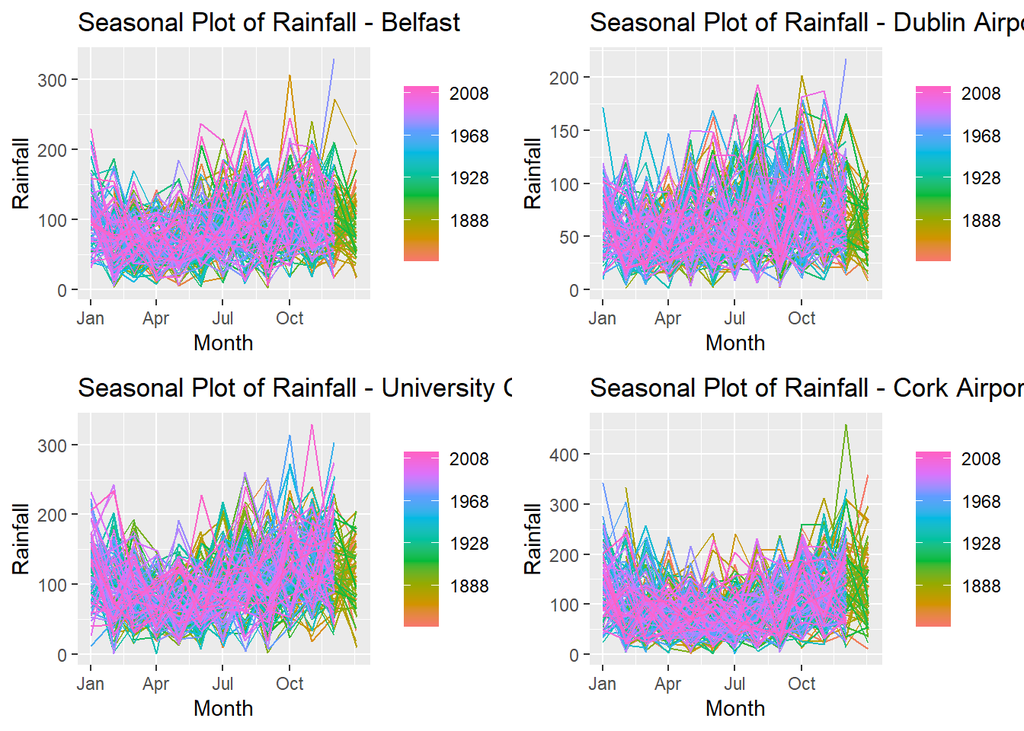

```r
data <- st_read('weather_stations.geojson', quiet=TRUE)

filter_stats <- c("Belfast","Dublin Airport","University College Galway","Cork Airport")
p_i <- list()

RAIN_pre <- as.data.frame(data) %>%
         dplyr::select(Year, Month, Rainfall, Station) %>%
         dplyr::filter(Station %in% filter_stats) %>%
         mutate(date = as.POSIXct(as.yearmon(paste0(Year, Month), "%Y %B")))
for(i in 1:4){
    RAIN <- as_tibble(RAIN_pre) %>%
        filter(Station == filter_stats[i]) %>%
        distinct(date, .keep_all = TRUE) %>%
        as_tsibble(index = date, regular = FALSE)

    p <- RAIN %>%
        gg_season(Rainfall, period = "year") +
        labs(title = paste0("Seasonal Plot of Rainfall - ", filter_stats[i]), x = "Month", y = "Rainfall")
    p

    p_i[[i]] <-p
}

# Combine the plots into one
grid.arrange(grobs = p_i, ncol = 2)
```

## 3 Shiny app:

There are three tabs, the first is the interactive map and time series showing the rainfall of each station over the years. This is the second and the third section helps to show the versatility of a shiny app. By accounting the user selection we can create graphical representation for any combination of weather stations.

### 3.1 User Interface (UI)

The ui is split into two main parts:

1. The map with weather station
- Contains a dropdown menu (`selectInput`) for station selection
- Displays a map of Ireland with station markers (`leafletOutput`)
2. Time series
- Shows the time series graph of rainfall data (`dygraphOutput`)

One can choose between the listed weather stations and also has the option to see them all. This will effect how the input is taken in by the server. By adding more `tabPanel(...)` we get analysis section and automated plots section.

```
tabsetPanel(
        tabPanel(
            title = "Map and Time series plot",
            sidebarPanel(
                leafletOutput(outputId = "map"),
                selectInput(
                    inputId = "variableselected",
                    label = "Select Station",
                    multiple = TRUE,
                    choices = c("All", stat_list),
                    selected = "All" # preset choice
                ),
                p("Map of Ireland and Stations")
            ),
            mainPanel(
                dygraphOutput(outputId = "timetrend")
            )
        ),
        .
        .
        .
```

### 3.2 Server

The server side takes in the input from the UI, alters the graphs and plots to show the requested values. First the server must make two function extracting the data that the graphs will require.

- `rainstat`: Loads and processes the main dataset for time series visualization.
- `map_data`: Prepares geographical data for the interactive map.

```
rainstat <- reactive({
        df = st_read('weather_stations.geojson', quiet=TRUE)
        as.data.frame(df) %>%
            dplyr::select(Year, Month, Rainfall, Station)
})

map_data <- reactive({
        st_read('weather_stations.geojson', quiet=TRUE) %>%
            dplyr::select(Station, geometry)
})
```

### 3.3 Timetrend

This by using the multiple argument in select Input and selecting those from the rainfall data set allows the plots to be correctly filtered.

If the user chooses to see all, then the code will define each station’s time series in a for loop and combine them into one dygraph seen in (i), adding the hover able element makes it easy for the user to view a specific station.

If just one or more stations is selected then this can be gotten from `input$variableselected`. Using the feature `dyRangeSelector(retainiDateWindow = TRUE...` from dygraph ensures consistent time range across station switches.

```
output$timetrend <- renderDygraph({
        rainstat <- rainstat()
        dataxts <- NULL

        if (is.null(input$variableselected)){
            showModal(modalDialog(
                title = "No Station Selected",
                "Please select at least one station.",
                easyClose = TRUE,
                footer = NULL
            ))
        }else{
            # (i) allows for correct filtering
            if( "All" %in% input$variableselected){
                filter_stats <- stat_list
            }else{
                filter_stats <- as.list(input$variableselected)
            }
            # print(length(filter_stats))

            for(l in 1:length(filter_stats)){
                rainstat %>% as.data.frame() %>%
                    dplyr::filter(Station == filter_stats[[l]]) %>%
                    dplyr::summarise(Rainfall=sum(Rainfall), .by = c(Year,Month)) %>%
                    pull(Rainfall)  -> data_station
                dd <- ts(
                    data <- as.data.frame(data_station),
                    start=c(1850,1), freq=12
                )

                dataxts <- cbind(dataxts,dd)
            }
            colnames(dataxts) <- filter_stats
            dygraph(dataxts, ylab = "Rainfall (mm)") %>%
                dyRangeSelector(retainDateWindow = TRUE) %>%
                dyHighlight(highlightSeriesBackgroundAlpha = 0.2) -> d1
            d1$x$css <- "
 .dygraph-legend > span {display:none;}
 .dygraph-legend > span.highlight { display: inline; }
 "
            d1
        }
    })
```

### 3.4 The next part is the map of Ireland:

The implementation of the interactive map of Ireland involves converting geometry data to longitude and latitude coordinates and creating a responsive leaflet map.

There are two variations that accounts if the user want to see all the station or just one:

- If only one station is chosen then again this is recognized using `input$variableselected`, and is filtered through the data set `rainstat_stats`.
- If “all” is choosen then instead the model would specify to use all of the four stations, seen under.

```
rainstat_stats <- rainstat %>% filter(Year == 1850)
            order_stats <- match(map$Station, rainstat_stats$Station)
            map$rain <- rainstat_stats[order_stats,]

            coords <- map %>%
                select(geometry) %>%
                st_coordinates() %>%
                as.data.frame() %>%
                rename(longitude = X, latitude = Y)

            map <- map %>%
                mutate(longitude = coords$longitude, latitude = coords$latitude)

            labels <- sprintf("%s", input$variableselected) %>%
                lapply(htmltools::HTML)
            l <- leaflet() %>%
                addTiles() %>%
                addMarkers(data = map,
                           lng = ~longitude, lat = ~latitude,
                           popup = map$Stations,
                           layerId = ~Station)
            l
```

Finally allowing the markers of the stations show the corresponding dygraph can be seen below. It asks to update the server end using the input defined in session.

```
observeEvent(input$map_marker_click, {
        click <- input$map_marker_click
        station <- click$id
        updateSelectInput(session, "variableselected", selected = station)
})
```

This interaction allows users to click on a station marker on the map and automatically update the time series graph to display data for that specific station. It creates a seamless connection between the geographical representation and the temporal data visualization, overall improving the user experience.

## 4 Conclusion

This interactive visualization tool provides valuable insights into Ireland’s rainfall patterns. The analysis reveals important findings on spatial variation, long-term and short-term trends, seasonal patterns, and data quality considerations. Using an interactive Shiny app helped to explore these patterns and trends in depth on nay number of stations allowing users to see an easy to understand graph.